# Un gráfico que mezcla dispersión y boxplots

Christian Salas-Eljatib, PhD

E-mail: cseljatib@gmail.com | Web: https://eljatib.com

Este código de R corresponde a la figura 6.10 del libro **Análisis de datos con el programa estadístico R: una introducción aplicada** de Salas-Eljatib (2021).

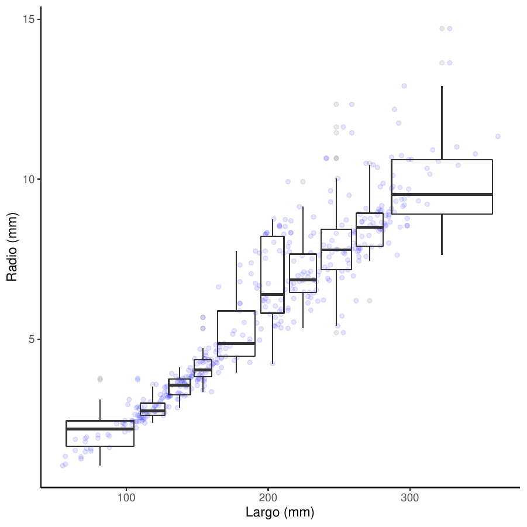

### Cargando los datos de ejemplo

Ocuparemos la dataframe **fishgrowth** del paquete *datana* de Salas-Eljatib, Riquelme, and Pino (2021).

```r
library(datana)
data(fishgrowth)
df <- fishgrowth
head(df) #primeras seis filas
```

```
  age length  scale
1   1     71 1.9061
2   1     64 1.8771
3   1     57 1.0974
4   1     68 1.3311
5   1     72 1.5928
6   1     80 1.9160
```

```r
nrow(df) #numero de filas de la dataframe
```

```
[1] 439
```

Estos datos contienen variables biometricas para individuos del pez *Micropterus dolomieu* en el lago West Bearskin del estado de Minnesota (USA). Estos datos provienen del paquete *alr4* Weisberg (2014) del libro de Weisberg (2013).

### El gráfico

Para realizar este gráfico basta símplemente con utilizar la función *xyBoxplot* del paquete *datana* de Salas-Eljatib (2021).

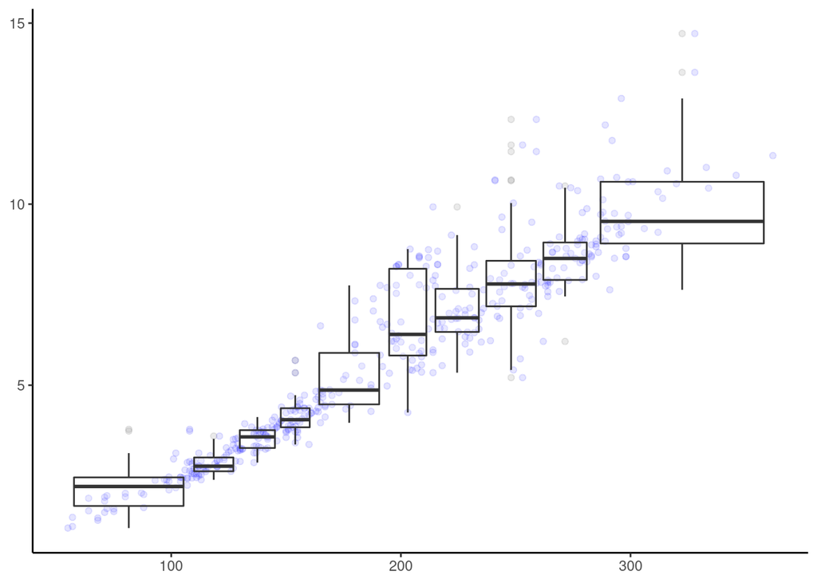

```r
xyBoxplot(x=df$length,y=df$scale) #aplicando la funcion con opciones por defecto
```

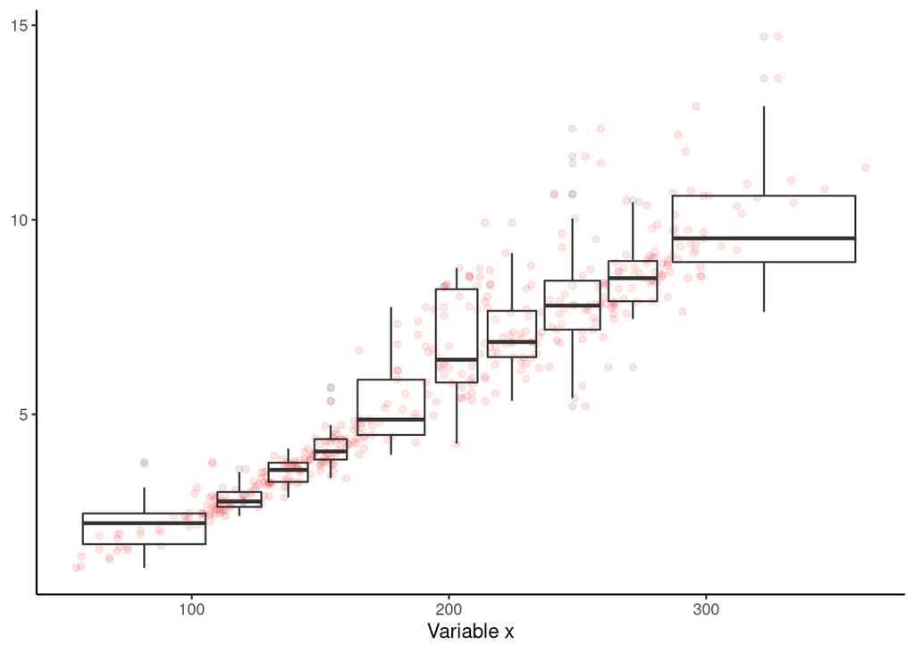

```r
xyBoxplot(x=df$length,y=df$scale, xlab="Variable x",
       col.dots = "red")#color de los puntos
```

### El gráfico del libro

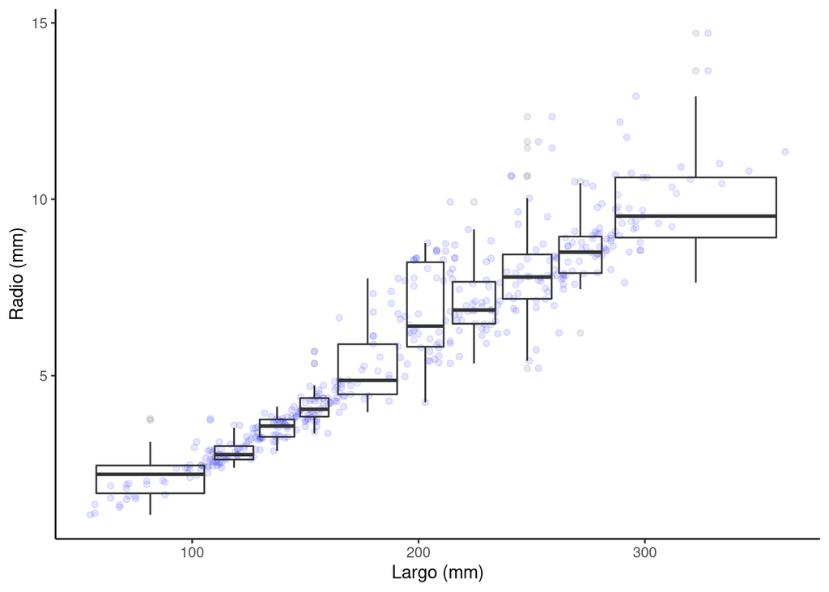

```r
xyBoxplot(x=df$length,y=df$scale, ylab="Radio (mm)",
       xlab="Largo (mm)")
```

Este gráfico puede ser de mucha utilidad tambien para cuando se esta analizando la homocedasticidad de los residuales de un modelo de regresion. Por ejemplo, ver la figura sobre residuales de un modelo estadístico para cada variable predictora en Salas, Stage, and Robinson (2008).

### Comentarios/sugerencias?

Cualquier error que encuentre en este ejemplo, comentario o sugerencia, no dude en contactarme vía e-mail. Muchas gracias desde ya.

## Bibliografía

Salas, C., A. R. Stage, and A. P. Robinson. 2008. “Modeling effects of overstory density and competing vegetation on tree height growth.” *Forest Sci.* 54 (1): 107–22. https://doi.org/10.1093/forestscience/54.1.107.

Salas-Eljatib, C. 2021. *Análisis de datos con el programa estadístico R: una introducción aplicada*. Santiago, Chile: Ediciones Universidad Mayor. https://tienda.zigzag.cl/9789566086109-analisis-de-datos-con-el-programa-estadistico-r.html.

Salas-Eljatib, C., J. Riquelme, and N. Pino. 2021. *`datana`: Data and functions to accompany Análisis de datos con el programa estadístico R: una introducción aplicada*. https://eljatib.com/rlibro/datana.pdf.

Weisberg, S. 2013. *Applied Linear Regression*. 4rd ed. USA: Wiley-Interscience.

———. 2014. *`alr4`: Methods and Data to Accompany Applied Linear Regression, Fourth Edition*. Hoboken, NJ: Wiley. http://z.umn.edu/alr4ed.